# covid-19: case data (import and processing)

## Import packages

```r
library(Rmisc)
library(tidyverse)
library(tidyquant)
library(ggplot2)
library(lubridate)
```

## Overview of notebook

Image or table of contents?

Making use of functions in external file

Set some notebook variables

## 1. Import datasets (Covid-19 cases)

Two data sets, cases:

1. **LSOA data:** Lower Super Output Area (LSOA) from https://coronavirus.data.gov.uk/about-data on 6th September 2020. For England only.
2. **Headline data:**

Notes on data import process (LSOA data):

- Initially the wk_10 column causing parsing errors because the parser in read_csv was guessing it was a logical column (as the first n rows contained NA as a value), so it was necessary to explicitly define wk_10 as an integer column.
- Counts between 0 and 2 are denoted by -99", I initially treated -99 as equivalent to NA when reading in the csv. But it might be better to replace -99 with a number, possbly 1?

Notes on data import process (Headline data):

- *none*

```r
# imported_lsoa_data
imported_lsoa = read_csv("LSOAs_latest.csv", na = c(-99, "NA"), col_types = cols(wk_10 = col_integer()))

# imported_headline_data
imported_headline <- read_csv("data_2020-Sep-07.csv")
```

## 2. Tidy data

### 2.1. Tidy LSOA Data

```r
tidy_lsoa_data <- function(df){
  df %>%
    pivot_longer(cols = `wk_05`:`wk_35`, names_to = "week", values_to = "cases") %>%

    mutate(
      week = as.integer(str_sub(week, 4, 5)),
      week_commencing = lubridate::ymd( "2019-12-30" ) + lubridate::weeks(week - 1)
    )
}

tidy_lsoa <- tidy_lsoa_data(imported_lsoa)
```

Then I quickly checked for missing data, by confirming that for each lower super output there are rows for all the weeks covered by the dataset (weeks 5 - 35 of 2020).

```r
number_of_distinct_values <- function(df, var_name){
    n_distinct(df[var_name])
}

num_lso <- number_of_distinct_values(tidy_lsoa, "lsoa11_nm")
num_weeks <- number_of_distinct_values(tidy_lsoa, "week")

num_obs <- nrow(tidy_lsoa)


stopifnot(num_lso * num_weeks == num_obs)
```

### 2.2. Tidy Headline Data

## 3. Processing data

### 3.1. Removing redudant variables

### 3.2. Formatting dates to enable comparision between Headline and LSOA data

### 3.3. Setting the geographic scope

### 3.4. Calculating weekly case numbers

## 4. Comparing the Headline and LSOA data

### 5. Exploring options for -99 entries in LSOA data

## Focus on Leeds cases

As I’m interested in Leeds in particular, I created a tibble of Leeds case data. But also I want to compare the data for Leeds to equivalent national data for England. As the number of cases in Leeds is likely to be a very small proportion of the total number of cases, I have also create a rest of England (i.e. England - Leeds) dataset for comparision.

```r
leeds_cases <- tidy_lsoa %>%
  filter(startsWith(lsoa11_nm, "Leeds"))

rest_of_england_cases <- tidy_lsoa %>%
  filter(!startsWith(lsoa11_nm, "Leeds"))

View(leeds_cases)
```

## Cases by week

I has quick look to see if there are any discrepancies between the UK Government covid-19 data portal (https://coronavirus.data.gov.uk/cases?areaType=nation&areaName=England) and the LSOA data analyzed here. Visual comparisons are not straight forward as the plots on the government data portal present cases per day. That said, around the peak the data portal reports between 3134 - 4796 new cases each day of the week commencing 20th April (so upwards of 20,000 cases for the week in total). While the LSOA data reports 12351 cases in total for the the week commencing 20th April.

```r
#
# get_cases_by_week <- function(df, na.rm = TRUE){
#   df %>%
#   group_by(week_commencing) %>%
#   summarise(weekly_cases = sum(cases, na.rm = na.rm))
# }

get_cases_by_week <- function(df, na.rm = TRUE, ...){
  ## ... used to pass additional variable names for grouping
  df %>%
  group_by(week_commencing, ...) %>%
  summarise(weekly_cases = sum(cases, na.rm = na.rm))
}

cases_per_week_national <- get_cases_by_week(tidy_lsoa)
cases_per_week_rest <- get_cases_by_week(rest_of_england_cases)
cases_per_week_leeds <- get_cases_by_week(leeds_cases)
```

### Comparing LSOA data with headline government data from coronavirus.data.gov.uk/

#### Importing headline data

```r
england_headline_data <- imported_headline %>%
  filter(areaName == "England") %>%
  arrange(date) %>%
  # remove redundant columns of data
  select(-c(areaType, areaCode, areaName)) %>%
  mutate(week_commencing = as_date(cut(date, "week")))

View(england_headline_data)

eng_head_data_by_week <- england_headline_data %>%
  group_by(week_commencing) %>%
  summarise(sum(newCasesBySpecimenDate))
View(eng_head_data_by_week)
```

#### comparing headline data with LSOA data

Plotting the cases over time for both the LSOA and Government headline datasets shows considerable differences in the number of cases recorded for each week. Although the overall trends in numbers of cases are similar both datasets, i.e. movements up or down in the number cases in the headline data tends to be track by similar movements in the LSOA data.

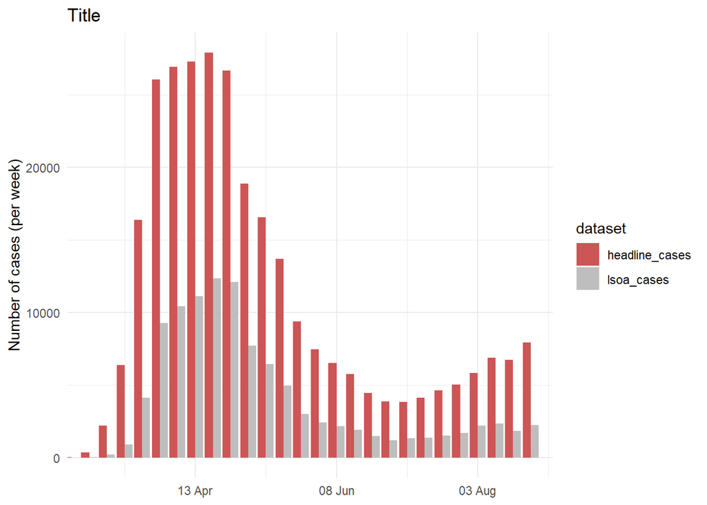

```r
cases_per_week_comparision <- function(lsoa_df, headline_df){
  lsoa_df %>%
  left_join(headline_df, by = "week_commencing") %>%
  rename(lsoa_cases = weekly_cases, headline_cases = `sum(newCasesBySpecimenDate)`) %>%
  pivot_longer(cols = c(lsoa_cases, headline_cases), names_to = "dataset", values_to = "cases")
}

cases_per_week_nat_comp <- cases_per_week_comparision(cases_per_week_national, eng_head_data_by_week)

# cases_per_week_nat_comp <- cases_per_week_national %>%
#   left_join(eng_head_data_by_week, by = "week_commencing") %>%
#   rename(lsoa_cases = weekly_cases, headline_cases = `sum(newCasesBySpecimenDate)`) %>%
#   pivot_longer(cols = c(lsoa_cases, headline_cases), names_to = "dataset", values_to = "cases")


cases_per_week_comp_plot <- function(df){
  ggplot(data = df, mapping = aes(x = week_commencing, y = cases, fill = dataset)) +
  geom_col(position = "dodge") +
  scale_fill_manual(values=c("indianred3" ,"grey")) +
  scale_x_date(date_breaks = "8 weeks", date_labels = "%d %b") +
  labs(x = NULL, y = "Number of cases (per week)", title = "Title") +
  coord_x_date(xlim = c("2020-03-02", "2020-08-24")) +
  theme_minimal()
}

cases_per_week_comp_plot(cases_per_week_nat_comp)
```

Given the scale of the differences between the case numbers in the two datasets, I’ll investigate these difference a little further. Below I plot the ratio between the number of cases in the two datasets. It shows that the headline dataset records between approximately 2 and 4 times as many cases as the LSOA dataset for the period after 16th March. The ratio is not plotted for earlier dates (i.e. early in the pandemic and pre-lockdown) as it is much larger, due to the relatively small number of cases reported in the LSOA dataset. So, I cropped the y axis of the graph to make it easier to view the variation in the ratio in the period since the initial period of ‘lockdown’ implemented by the Government in March 2020.

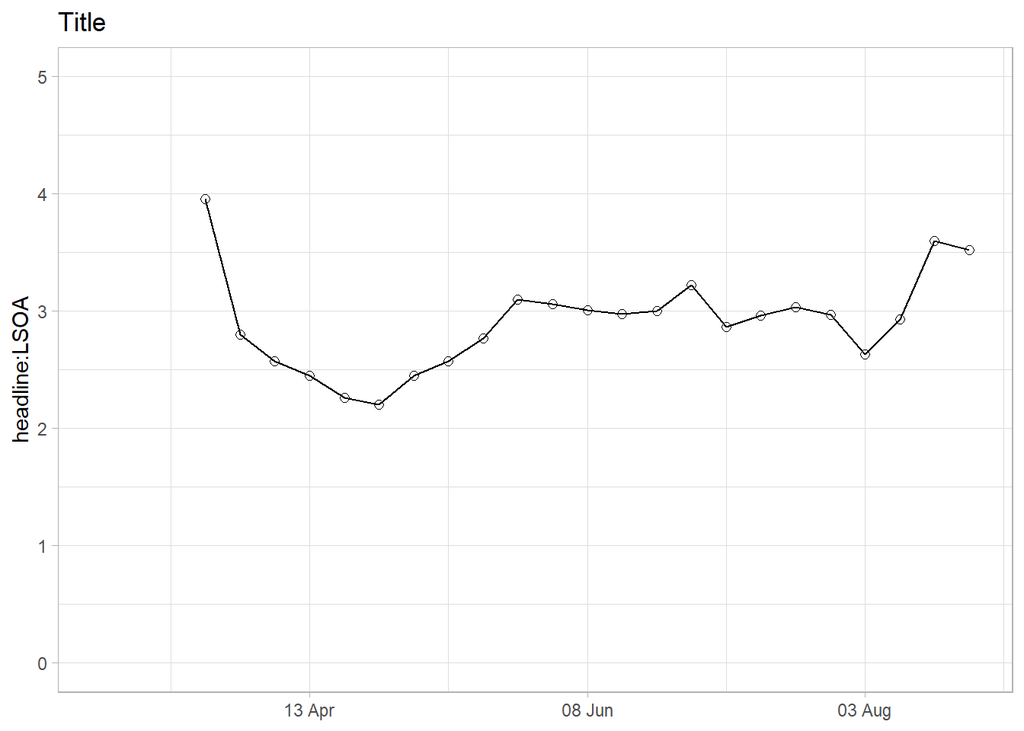

```r
cases_per_week_nat_comp %>%
  pivot_wider(names_from = dataset, values_from = cases) %>%
  mutate(
    `headline:LSOA` = headline_cases / lsoa_cases
  ) %>%
  mutate(`headline:LSOA` = replace(`headline:LSOA`, `headline:LSOA` == Inf, NA)) %>%

  ggplot(mapping = aes(x = week_commencing, y = `headline:LSOA`)) +
  geom_line() +
  geom_point(shape = 1, size = 2) +
  scale_x_date(date_breaks = "8 weeks", date_labels = "%d %b") +
  scale_y_continuous(limits = c(0, 5)) +
  labs(x = NULL, title = "Title") +
  coord_x_date(xlim = c("2020-03-02", "2020-08-24")) +
  theme_light()
```

I thought it was worth checking the differences in the number cases in the headline and LSOA datasets were not created by the processing in this notebook. So, I quickly crosschecked the total number of cases recorded in the two datasets, which again showed large differences.

```r
# lsoa
crosscheck_lsoa <- imported_lsoa
crosscheck_lsoa$lsoa_case_tot <- crosscheck_lsoa %>%
  select(wk_05:wk_35) %>%
  rowSums(na.rm = TRUE)

total_cases_lsoa <- sum(crosscheck_lsoa$lsoa_case_tot)

#headline data
crosscheck_headline <- imported_headline %>%
  filter(areaName == "England") %>%
  filter(date == as_date("2020-08-30"))

total_cases_headline <- crosscheck_headline$cumCasesBySpecimenDate
```

**Total cases (lsoa dataset)**:106752

**Total cases (headline dataset)**: 292025

It appears there are major differences in the ways in which cases are recorded in the headline and lsoa datasets. With only 36.6% of cases recorded in the headline dataset appearing in the LSOA dataset. So, I emailed the contact on the https://coronavirus.data.gov.uk website to ask for further advice, and received the following reply.

09/09/2020 from coronavirus-tracker@phe.gov.uk

"Hi Chris,

We have to suppress the number of cases if they are below 3, hence the LSOA file will not show if there were 1 or 2 cases in an area and they will be missed in the totals.

Regards"

**An opportunity to learn about lists and iteration**

```r
# define sets of probabilities for NA (coded -99 in source data) being replaced by 0, 1 or 2
# probabilities stored as a list of vectors.

probabilities <- list(
  #         c(p(0), p(1), p(2))
  probs_1 = c(1, 0, 0),
  probs_2 = c(0, 1, 0),
  probs_3 = c(0, 0, 1),
  probs_4 = c( 1 / 3, 1 / 3, 1 / 3)
)

cases_lsoa_processing_options <- tidy_lsoa

# for each set of probabilities create a new column cases in the df and label accordingly
for (i in seq_along((probabilities))){
  # create columns for cases by processing option
  col_name <- str_c("proc_", i, "_cases")
  cases_lsoa_processing_options[col_name] <- cases_lsoa_processing_options["cases"]

  # replace na with c(0, 1, 2) according to probabilities defined above
  cases_lsoa_processing_options[[col_name]][is.na(cases_lsoa_processing_options[[col_name]])] <-
    sample(
      c(0,1,2),
      size = sum(is.na(cases_lsoa_processing_options[[col_name]])),
      prob = probabilities[[i]],
      replace = TRUE
    )

}

# # add headline date into the tibble
# cases_lsoa_processing_options <- cases_lsoa_processing_options %>%
#   left_join(y = eng_head_data_by_week, by = "week_commencing")


cases_lsoa_processing_options_tidy <- cases_lsoa_processing_options %>%
  # tidy data
  relocate(week_commencing, .after = week) %>%
  rename(source_cases = cases) %>%
  pivot_longer(cols = source_cases:ncol(cases_lsoa_processing_options), values_to = "cases", names_to = "processing") %>%

  # calculate case numbers per week (for each processing approach)
  get_cases_by_week(na.rm = TRUE, processing) %>%

  # add in headline data for comparison
  pivot_wider(names_from = processing, values_from = weekly_cases) %>%
  left_join(y = eng_head_data_by_week, by = "week_commencing") %>%
  rename(headline_cases = `sum(newCasesBySpecimenDate)`) %>%
  pivot_longer(cols = proc_1_cases:headline_cases, names_to = "source", values_to = "cases")
```

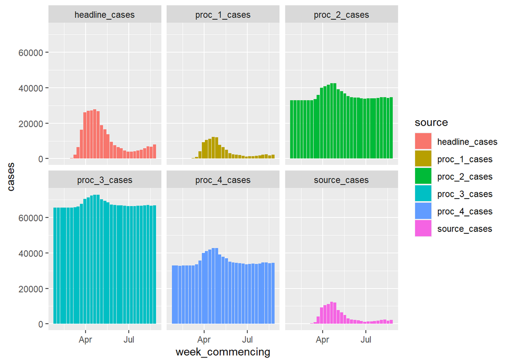

```r
#View(cases_lsoa_processing_options_tidy)


#cases_per_wk_processing_options_tidy <- get_cases_by_week(cases_lsoa_processing_options_tidy, na.rm = FALSE, processing)
View(cases_lsoa_processing_options_tidy)

# Facet plot the alternative approaches to processing NA (coded as -99 in source data)values
ggplot(data = cases_lsoa_processing_options_tidy, mapping = aes(
        x = week_commencing, y = cases, fill = source)) +
  geom_col() +
  facet_wrap(~ source)
```

```r
cases_lsoa_p2 <- tidy_lsoa
#   mutate(cases = replace_na(cases, sample(0:2, 1, replace = TRUE, prob = c(0.6, 0.25, 0.15))))

cases_lsoa_p2$cases[is.na(cases_lsoa_p2$cases)] <- sample(
  c(0,1,2),
  size=sum(is.na(cases_lsoa_p2$cases)),
  prob = c(0.5, 0.25, 0.25),
  replace=TRUE
  )

#sample(c(0, 1, 2), 1, replace = TRUE)

sum(cases_lsoa_p2$cases)
```

```
## [1] 853062
```

```r
cases_per_week_lsoa_p2 <- get_cases_by_week(cases_lsoa_p2)
```

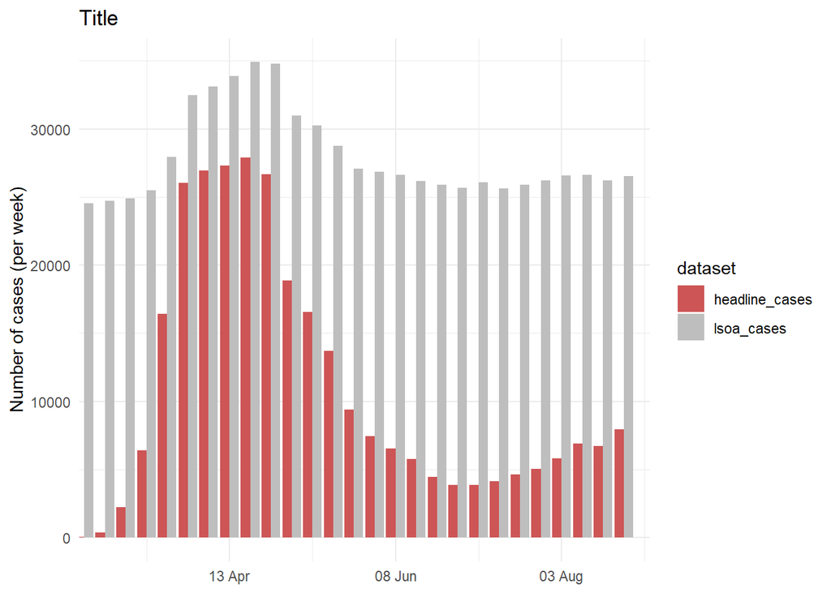

```r
cases_per_week_nat_comp_p2 <- cases_per_week_comparision(cases_per_week_lsoa_p2, eng_head_data_by_week)
cases_per_week_comp_plot(cases_per_week_nat_comp_p2)
```

## Initial plots

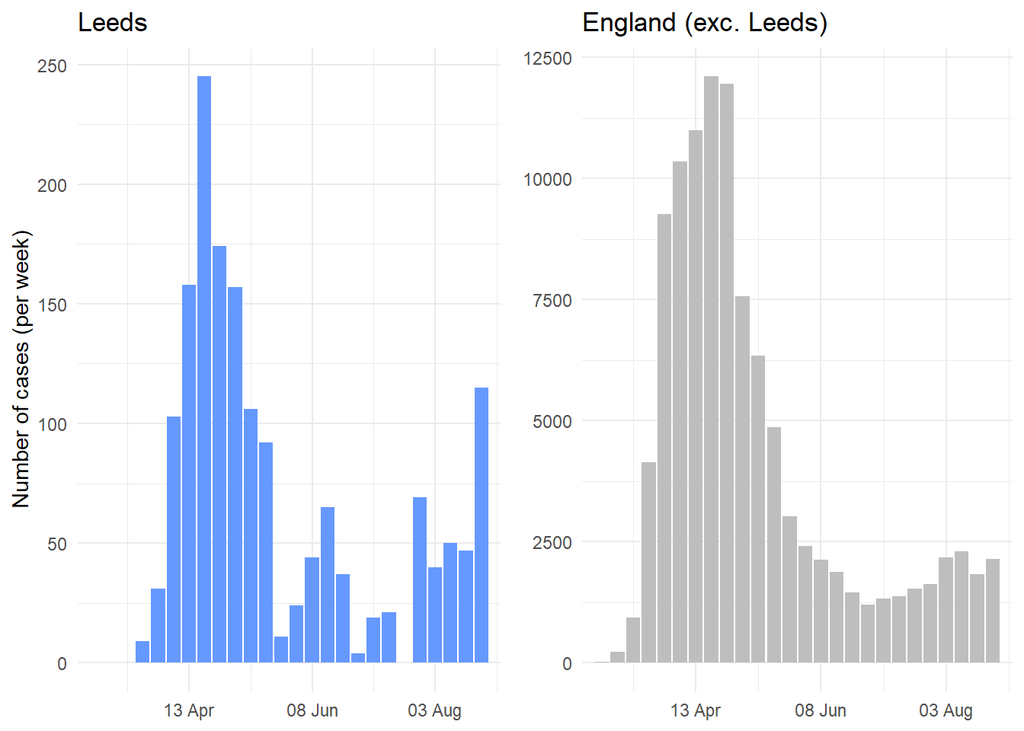

```r
p_leeds <- ggplot(data = cases_per_week_leeds, mapping = aes(
    x = week_commencing , y = weekly_cases)
  ) +
  geom_col(fill = "#6699FF") +
  scale_x_date(date_breaks = "8 weeks", date_labels = "%d %b") +
  labs(x = NULL, y = "Number of cases (per week)", title = "Leeds") +
  coord_x_date(xlim = c("2020-03-02", "2020-08-24")) +
  theme_minimal()

p_national <- ggplot(data = cases_per_week_rest, mapping = aes(
    x = week_commencing , y = weekly_cases)
  ) +
  geom_col(fill = "grey") +
  scale_x_date(date_breaks = "8 weeks", date_labels = "%d %b") +
  labs(x = NULL, y = NULL, title = "England (exc. Leeds)") +
  coord_x_date(xlim = c("2020-03-02", "2020-08-24")) +
  theme_minimal()

multiplot(p_leeds, p_national, cols = 2)
```

```r
# plot(p_national)
# plot(p_leeds)
```

## Ideas

- against national trends
  - proportions of cases
- Against hotspots / places with local lockdowns https://www.instituteforgovernment.org.uk/explainers/coronavirus-local-lockdowns
- correlation
  - cases and household type https://www.nomisweb.co.uk/census/2011/ks403ew
  - cases and self report tool symptoms https://covid.joinzoe.com/data
  - cases and deprivation https://github.com/britishredcrosssociety/covid-19-vulnerability